# Štrajky

Súbor STRIKES.DAT obsahuje dáta o ročnom počte štrajkov v USA v rokoch 1951-1980.

#### Načítanie a zobrazenie dát

```r
STRIKES <- read.table("STRIKES.DAT")
str(STRIKES)
```

```
## 'data.frame':    30 obs. of  1 variable:
##  $ V1: int  4737 5117 5091 3468 4320 3825 3673 3694 3708 3333 ...
```

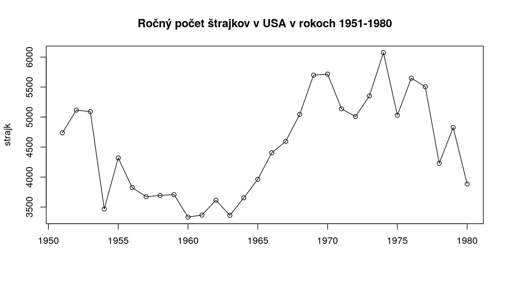

```r
strajk<-STRIKES$V1
plot(1951:1980,strajk, type="o", main = " Ročný počet štrajkov v USA v rokoch 1951-1980 ", xlab ="")
```

#### Pozorovanie

- bez sezónnej zložky a bez trendu
- nárast okolo roku 1970 spôsobený krízou

Ak rad nemá ani sezónnu zložku, ani trend tak možno použiť jednoduché exponenciálne vyrovnávanie. Metóda je odvodená od metódy kĺzavých priemerov ale má výhodu v tom, že nestrácame dáta.

**Definícia**

*Rad exponenciálnych priemerov je definovaný rekurentným vzťahom*
$$y_1=x_1$$
$$y_t=\alpha x_t + (1-\alpha) y_{t-1}, t=2,3,...n,$$
*kde $\alpha\in (0,1)$ je zvolená konštanta.*

Zrejme je $y_t=\alpha x_t + (1-\alpha) y_{t-1}=$

$=\alpha x_t + \alpha(1-\alpha) x_{t-1}+(1-\alpha)^2y_{t-2}=$

$=\alpha x_t + \alpha(1-\alpha) x_{t-1}+\alpha(1-\alpha)^2x_{t-2}+(1-\alpha)^3y_{t-3}=$

$=\alpha x_t + \alpha(1-\alpha) x_{t-1}+\alpha(1-\alpha)^2x_{t-2}+\alpha(1-\alpha)^3x_{t-3}+(1-\alpha)^4y_{t-4}= ...$

Z pohľadu na rekurentný vzťah vidíme, že $1-\alpha$ hrá úlohu váhy. Ak $\alpha = 1$, tak dostaneme pôvodný rad. Pre $\alpha \approx 1$, tak máme podobný rad ako bol pôvodný. Vyrovnávame málo a prejavujú sa vo veľkom náhodné javy. Keď $\alpha \approx 0$, tak sa rad “veľmi vyrovnáva” a staršie dáta hrajú oveľa väčšiu úlohu a môžu nám ujsť trendy. Ani jeden z extrémov nie je dobrý. Optimálnu hodnotu $\alpha$ nájdeme tak, že “najlepšie vyhladí” naše dáta.

Pri tejto metóde vyrovnávania je možné robiť predikciu na jedno obdobie dopredu. Predikciou hodnoty $x_{n+1}$ je exponenciálny priemer v čase $n$:
$$\hat{x}_{n+1}=y_n.$$

#### Exponenciálne vyrovnávanie v R

V R je metóda naprogramovaná ako špeciálny prípad tzv. Holterovej-Wintersovej metódy (filtra). Metóda má tri parametre, pre $\beta = 0$ a $\gamma = 0$ dostaneme, čo chceme.

```r
strajkHW <- HoltWinters(strajk, alpha = 0.4, beta = FALSE, gamma = FALSE)
strajkHW
```

```
## Holt-Winters exponential smoothing without trend and without seasonal component.
##
## Call:
## HoltWinters(x = strajk, alpha = 0.4, beta = FALSE, gamma = FALSE)
##
## Smoothing parameters:
##  alpha: 0.4
##  beta : FALSE
##  gamma: FALSE
##
## Coefficients:
##       [,1]
## a 4506.279
```

```r
shw = strajkHW$fitted[,1]
shw
```

```
## Time Series:
## Start = 2
## End = 30
## Frequency = 1
##  [1] 4737.000 4889.000 4969.800 4369.080 4349.448 4139.669 3953.001
##  [8] 3849.401 3792.840 3608.904 3512.143 3552.886 3476.531 3547.919
## [15] 3713.951 3990.371 4232.222 4557.333 5014.400 5295.040 5232.224
## [22] 5143.334 5227.201 5565.920 5351.952 5470.371 5484.623 4982.774
## [29] 4920.464
```

```r
a = strajkHW$coefficients
a
```

```
##        a
## 4506.279
```

#### Odhad $\alpha$ pomocou R

Parameter $\alpha$ nemusíme zadávať, softwér sa ho pokúsi optimalizovať.

```r
strajkHW <- HoltWinters(strajk, beta = FALSE, gamma = FALSE)
strajkHW
```

```
## Holt-Winters exponential smoothing without trend and without seasonal component.
##
## Call:
## HoltWinters(x = strajk, beta = FALSE, gamma = FALSE)
##
## Smoothing parameters:
##  alpha: 0.6824642
##  beta : FALSE
##  gamma: FALSE
##
## Coefficients:
##       [,1]
## a 4165.037
```

```r
strajkHW$alpha
```

```
## [1] 0.6824642
```

```r
shw = strajkHW$fitted[,1]
shw
```

```
## Time Series:
## Start = 2
## End = 30
## Frequency = 1
##  [1] 4737.000 4996.336 5060.941 3973.816 4210.074 3947.275 3760.092
##  [8] 3714.987 3710.218 3452.780 3394.238 3544.218 3419.861 3580.335
## [15] 3841.490 4226.065 4477.850 4864.910 5434.829 5626.718 5293.185
## [22] 5099.922 5272.639 5819.539 5281.389 5531.588 5514.125 4637.756
## [29] 4766.908
```

```r
a = strajkHW$coefficients
a
```

```
##        a
## 4165.037
```

#### Znázornenie pôvodného ČR a vyrovnaného ČR

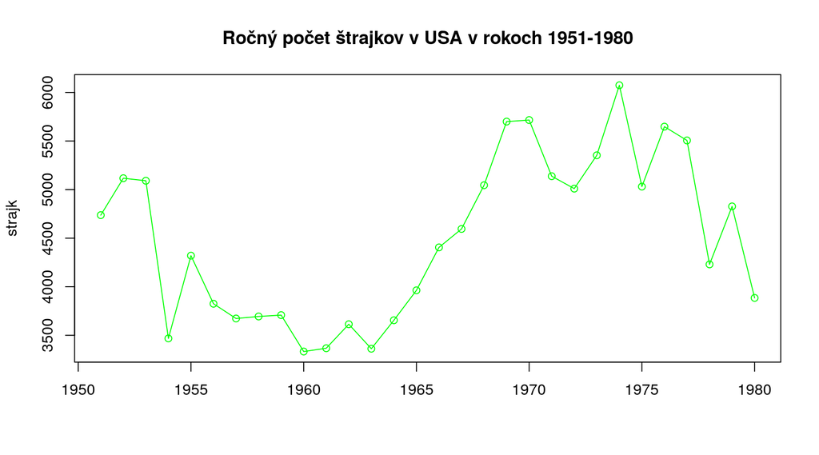

```r
plot(1951:1980,strajk, type="o", main = " Ročný počet štrajkov v USA v rokoch 1951-1980 ", xlab ="", col='green')
lines(shw, col = 'cyan')
```

Vyrovnávanie

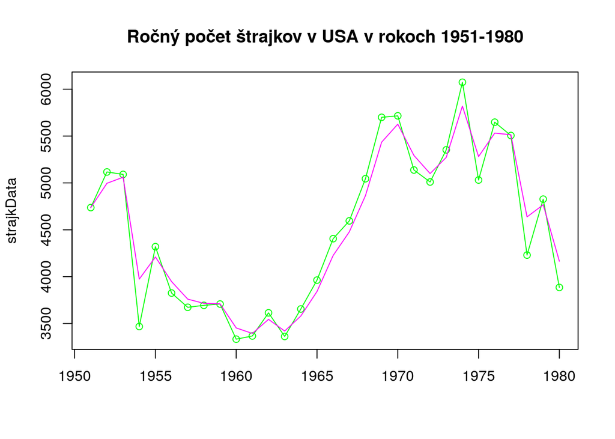

```r
shwdata <- ts(c(shw,a), start = 1951)
strajkData = ts(strajk, start = 1951)
plot(strajkData, type="o", main = " Ročný počet štrajkov v USA v rokoch 1951-1980 ", xlab ="", col='green')
lines(shwdata, col = 'magenta')
```

**Posledná vyrovnaná hodnota je považovaná za predikciu.**

#### Výpočet a znázornenie reziduí

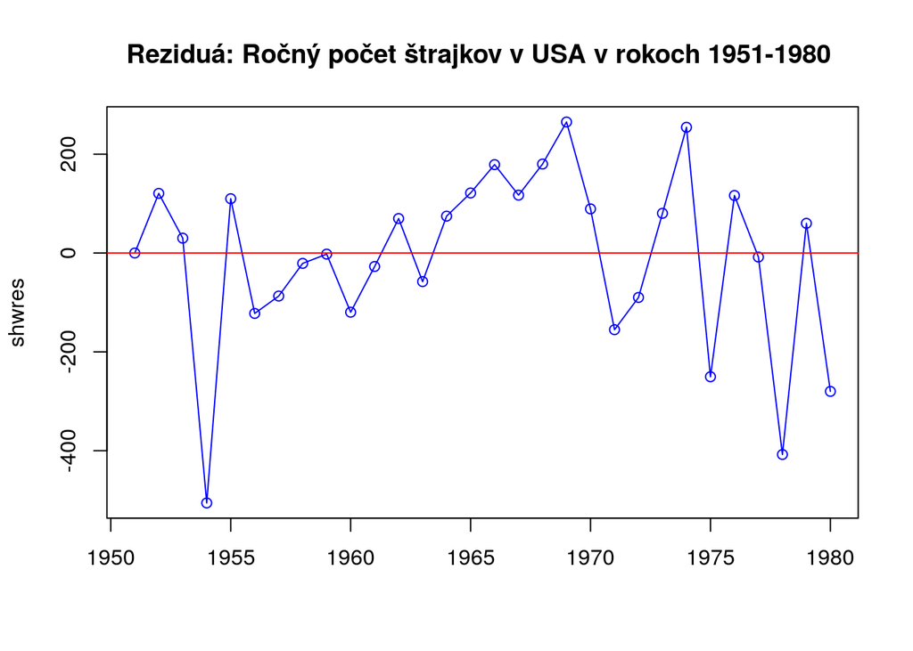

```r
shwres <- strajkData-shwdata
plot(shwres, type="o", main = "Reziduá: Ročný počet štrajkov v USA v rokoch 1951-1980 ", xlab ="", col='blue')
abline(0,0, col = 'red')
```

#### Možno reziduá považovať za nezávislé dáta?

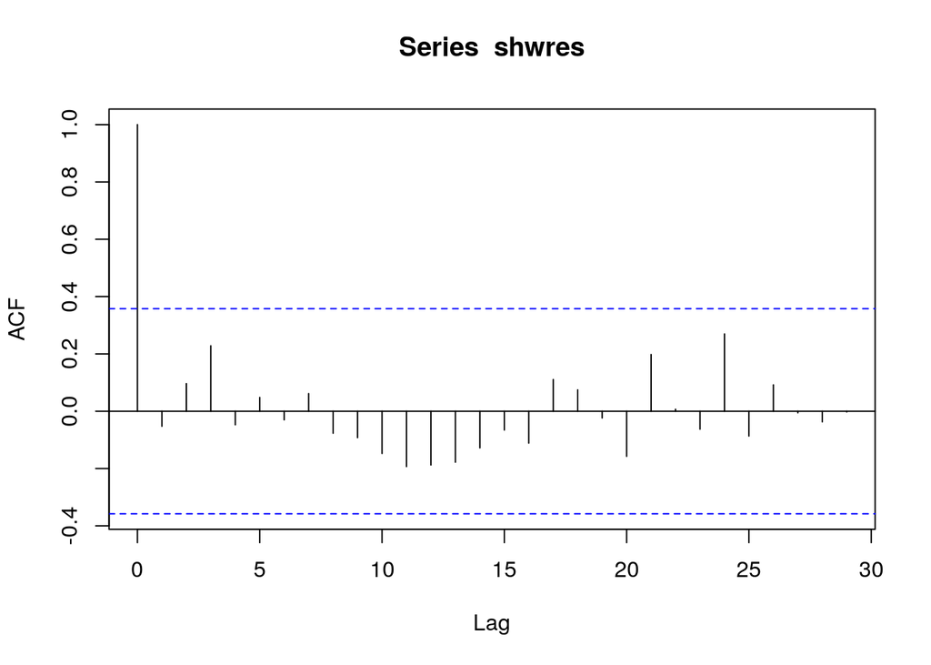

```r
acf(shwres, 40)
```

```r
Box.test(strajkData)
```

```
##
##  Box-Pierce test
##
## data:  strajkData
## X-squared = 16.089, df = 1, p-value = 6.043e-05
```

```r
Box.test(strajkData, type = 'Ljung')
```

```
##
##  Box-Ljung test
##
## data:  strajkData
## X-squared = 17.754, df = 1, p-value = 2.514e-05
```

**IID test:** Všetky hodnoty sú v intervale, čiže je to OK. Ale treba si dávať pozor, máme menej ako 40 dát.